# Czas reakcji przed i po spożyciu alkoholu

Test t-Studenta dla prób zależnych — wersja studencka do uzupełienia

Materiały dydaktyczne

# 1 Cel analizy

W tym przykładzie analizujemy czasy reakcji tej samej grupy 25 kierowców przed oraz po wypiciu 100 g alkoholu. Naszym zadaniem jest sprawdzenie, czy przeciętny czas reakcji po alkoholu różni się od przeciętnego czasu reakcji przed alkoholem.

Ponieważ te same osoby zostały zmierzone dwukrotnie, mamy do czynienia z **próbami zależnymi**. W takiej sytuacji nie porównujemy dwóch niezależnych grup, ale analizujemy zmianę wyniku w parach pomiarów: przed i po.

# 2 Przygotowanie środowiska

```r
install.packages(c(
  "tidyverse",
  "janitor",
  "broom",
  "knitr"
))
```

```r
library(tidyverse)
library(janitor)
library(broom)
library(knitr)
```

```r
alpha <- 0.05
```

# 3 Import danych

Dane znajdują się w pliku `Czas reakcji.csv`. Plik zawiera dwa pomiary dla każdego kierowcy:

- `Reakcja_przed` - czas reakcji przed spożyciem alkoholu,
- `Reakcja_po` - czas reakcji po spożyciu alkoholu.

```r
raw_data <- readr::read_delim(
  file = "Czas reakcji.csv",
  delim = ";",
  locale = readr::locale(decimal_mark = ",", encoding = "UTF-8"),
  show_col_types = FALSE
)

head(raw_data)
```

| Reakcja_przed | Reakcja_po |
| --- | --- |
| 0.17 | 0.22 |
| 0.22 | 0.30 |
| 0.25 | 0.22 |
| 0.19 | 0.26 |
| 0.15 | 0.19 |
| 0.20 | 0.24 |

# 4 Przygotowanie danych

Porządkujemy nazwy zmiennych i tworzymy dodatkową zmienną `reaction_diff`, czyli różnicę między czasem reakcji po alkoholu i przed alkoholem.

Dodatnia wartość `reaction_diff` oznacza, że czas reakcji po alkoholu był dłuższy niż przed alkoholem.

```r
reaction_data <- raw_data |>
  janitor::clean_names() |>
  dplyr::rename(
    reaction_before = reakcja_przed,
    reaction_after  = reakcja_po
  ) |>
  dplyr::mutate(
    driver_id = dplyr::row_number(),
    reaction_diff = reaction_after - reaction_before
  ) |>
  tidyr::drop_na(reaction_before, reaction_after, reaction_diff)

head(reaction_data)
```

| reaction_before | reaction_after | driver_id | reaction_diff |
| --- | --- | --- | --- |
| 0.17 | 0.22 | 1 | 0.05 |
| 0.22 | 0.30 | 2 | 0.08 |
| 0.25 | 0.22 | 3 | -0.03 |
| 0.19 | 0.26 | 4 | 0.07 |
| 0.15 | 0.19 | 5 | 0.04 |
| 0.20 | 0.24 | 6 | 0.04 |

# 5 Wybór testu

W tym przykładzie porównujemy dwa pomiary wykonane u tych samych osób: czas reakcji przed spożyciem alkoholu oraz czas reakcji po spożyciu alkoholu. Nie są to więc dwie niezależne grupy, tylko **dwa powiązane pomiary** tej samej grupy kierowców.

Z tego powodu właściwym testem parametrycznym jest **test t-Studenta dla prób zależnych**. W praktyce taki test nie analizuje dwóch kolumn całkowicie oddzielnie, lecz sprawdza, czy średnia różnica między pomiarem po i przed alkoholem różni się od zera.

W tej analizie różnicę definiujemy jako:

$$\text{reaction_diff} =
\text{reaction_after} - \text{reaction_before}$$

Dodatnia wartość różnicy oznacza wydłużenie czasu reakcji po spożyciu alkoholu. Ujemna wartość oznaczałaby krótszy czas reakcji po alkoholu.

Przed wykonaniem testu t dla prób zależnych sprawdzimy normalność rozkładu różnic. Jeżeli rozkład różnic silnie odbiegałby od normalnego, można byłoby rozważyć nieparametryczny test Wilcoxona dla prób zależnych. W tym materiale główną procedurą pozostaje jednak test t-Studenta dla prób zależnych.

# 6 Kontrola struktury danych

Sprawdź strukturę przygotowanej ramki danych `reaction_data`. Zwróć uwagę, czy kolumny `reaction_before` i `reaction_after` są zmiennymi liczbowymi oraz czy została poprawnie utworzona kolumna z różnicą `reaction_diff`.

```r
dplyr::glimpse(reaction_data)
```

```
## Rows: 25
## Columns: 4
## $ reaction_before <dbl> 0.17, 0.22, 0.25, 0.19, 0.15, 0.20, 0.19, 0.23, 0.16, …
## $ reaction_after  <dbl> 0.22, 0.30, 0.22, 0.26, 0.19, 0.24, 0.29, 0.22, 0.24, …
## $ driver_id       <int> 1, 2, 3, 4, 5, 6, 7, 8, 9, 10, 11, 12, 13, 14, 15, 16,…
## $ reaction_diff   <dbl> 0.05, 0.08, -0.03, 0.07, 0.04, 0.04, 0.10, -0.01, 0.08…
```

W danych znajduje się 25 kompletnych par pomiarów. Każdy wiersz odpowiada jednemu kierowcy.

Sprawdź, ile osób znajduje się w analizowanym zbiorze danych. Każdy wiersz odpowiada jednemu kierowcy, u którego zmierzono czas reakcji przed i po spożyciu alkoholu.

```r
nrow(reaction_data)
```

```
## [1] 25
```

```r
length(unique(reaction_data$driver_id))
```

```
## [1] 25
```

# 7 Statystyki opisowe

Najpierw porównujemy średnie i odchylenia standardowe czasu reakcji przed oraz po spożyciu alkoholu.

Oblicz podstawowe statystyki opisowe dla czasu reakcji przed alkoholem, po alkoholu oraz dla różnicy `reaction_diff`. W danych zależnych różnica między pomiarami jest bardzo ważna, ponieważ to właśnie ona jest później analizowana w teście t dla prób zależnych.

```r
descriptive_summary <- reaction_data |>
  dplyr::summarise(
    n = dplyr::n(),
    mean_before = mean(reaction_before),
    sd_before = sd(reaction_before),
    median_before = median(reaction_before),
    mean_after = mean(reaction_after),
    sd_after = sd(reaction_after),
    median_after = median(reaction_after),
    mean_difference = mean(reaction_diff),
    sd_difference = sd(reaction_diff),
    median_difference = median(reaction_diff)
  )

descriptive_summary |>
  knitr::kable(
    digits = 4,
    caption = "Statystyki opisowe czasów reakcji przed i po alkoholu"
  )
```

Statystyki opisowe czasów reakcji przed i po alkoholu

| n | mean_before | sd_before | median_before | mean_after | sd_after | median_after | mean_difference | sd_difference | median_difference |
| --- | --- | --- | --- | --- | --- | --- | --- | --- | --- |
| 25 | 0.2012 | 0.0318 | 0.19 | 0.2688 | 0.0457 | 0.26 | 0.0676 | 0.0506 | 0.07 |

Średni czas reakcji przed spożyciem alkoholu wynosi około 0,201 s, natomiast po spożyciu alkoholu około 0,269 s. Średnia różnica wynosi około 0,068 s, co oznacza wydłużenie czasu reakcji po alkoholu.

# 8 Dane w formacie długim

Do wygodnego tworzenia wykresów przekształcimy dane z formatu szerokiego do formatu długiego.

Poniższy fragment przekształca dane z układu szerokiego do długiego. Dzięki temu łatwiej przygotować wykresy porównujące czasy reakcji przed i po spożyciu alkoholu. Kod zostawiamy gotowy, ponieważ jest to krok techniczny związany głównie z przygotowaniem danych do wizualizacji.

```r
reaction_long <- reaction_data |>
  dplyr::select(driver_id, reaction_before, reaction_after) |>
  tidyr::pivot_longer(
    cols = c(reaction_before, reaction_after),
    names_to = "measurement",
    values_to = "reaction_time"
  ) |>
  dplyr::mutate(
    measurement = dplyr::recode(
      measurement,
      reaction_before = "Przed alkoholem",
      reaction_after  = "Po alkoholu"
    ),
    measurement = factor(
      measurement,
      levels = c("Przed alkoholem", "Po alkoholu")
    )
  )

head(reaction_long)
```

| driver_id | measurement | reaction_time |
| --- | --- | --- |
| 1 | Przed alkoholem | 0.17 |
| 1 | Po alkoholu | 0.22 |
| 2 | Przed alkoholem | 0.22 |
| 2 | Po alkoholu | 0.30 |
| 3 | Przed alkoholem | 0.25 |
| 3 | Po alkoholu | 0.22 |

# 9 Wizualizacja danych

Dla danych zależnych szczególnie użyteczny jest wykres, na którym połączymy pomiary tej samej osoby. Dzięki temu widzimy, czy większość kierowców ma dłuższy czas reakcji po alkoholu.

Kod zostawiamy gotowy, ponieważ głównym celem ćwiczenia jest wykonanie testu t dla prób zależnych, a nie samodzielne przygotowanie bardziej złożonego wykresu.

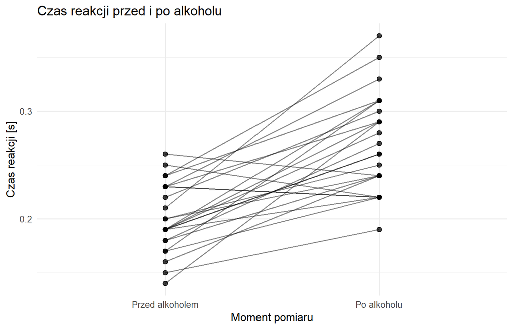

```r
ggplot(reaction_long, aes(x = measurement, y = reaction_time, group = driver_id)) +
  geom_line(alpha = 0.45) +
  geom_point(size = 2, alpha = 0.75) +
  labs(
    title = "Czas reakcji przed i po alkoholu",
    x = "Moment pomiaru",
    y = "Czas reakcji [s]"
  ) +
  theme_minimal()
```

Na wykresie widać, że u większości kierowców czas reakcji po alkoholu jest dłuższy niż przed alkoholem.

Dodatkowo można porównać rozkłady obu pomiarów za pomocą wykresu ramka-wąsy. Trzeba jednak pamiętać, że taki wykres nie pokazuje bezpośrednio parowania obserwacji, dlatego w danych typu przed-po wykres połączonych par jest zwykle bardziej informacyjny.

Przygotuj wykres ramka-wąsy pokazujący rozkłady zmiennej `reaction_time` w grupach wyznaczonych przez `measurement`. Dodaj pojedyncze obserwacje jako punkty.

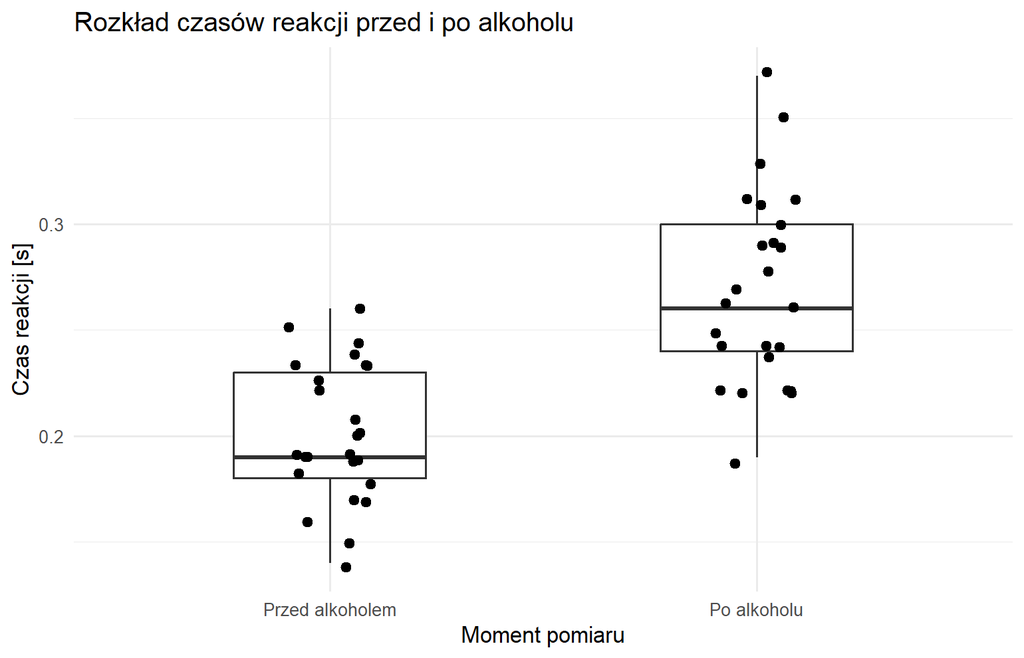

```r
ggplot(reaction_long, aes(x = measurement, y = reaction_time)) +
  geom_boxplot(
    width = 0.45,
    outlier.shape = NA
  ) +
  geom_jitter(
    width = 0.1,
    size = 2,
    alpha = 1
  ) +
  labs(
    title = "Rozkład czasów reakcji przed i po alkoholu",
    x = "Moment pomiaru",
    y = "Czas reakcji [s]"
  ) +
  theme_minimal()
```

# 10 Ocena normalności rozkładu różnic

W przypadku testu t dla prób zależnych założenie normalności dotyczy przede wszystkim **rozkładu różnic**, a nie oddzielnie rozkładu obu pomiarów.

Wykonaj test Shapiro-Wilka dla zmiennej `reaction_diff`. Wynik zapisz w obiekcie `shapiro_result`.

## 10.1 Test Shapiro-Wilka dla różnic

```r
shapiro.test(reaction_data$reaction_diff)
```

```
##
##  Shapiro-Wilk normality test
##
## data:  reaction_data$reaction_diff
## W = 0.9688, p-value = 0.6149
```

Wartość p w teście Shapiro-Wilka wynosi około 0,615, czyli jest większa od przyjętego poziomu istotności 0,05. Nie mamy więc podstaw do odrzucenia założenia normalności rozkładu różnic.

## 10.2 Wykres Q-Q dla różnic

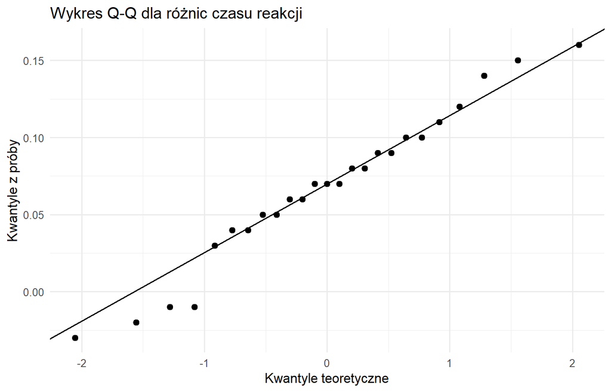

```r
ggplot(reaction_data, aes(sample = reaction_diff)) +
  stat_qq(size = 2) +
  stat_qq_line() +
  labs(
    title = "Wykres Q-Q dla różnic czasu reakcji",
    x = "Kwantyle teoretyczne",
    y = "Kwantyle z próby"
  ) +
  theme_minimal()
```

Wykres Q-Q nie wskazuje na silne odstępstwa od normalności. Możemy więc zastosować test t-Studenta dla prób zależnych.

# 11 Test t-Studenta dla prób zależnych

Wykonujemy test t-Studenta dla prób zależnych. W funkcji `t.test()` ustawiamy argument `paired = TRUE`, ponieważ porównujemy dwa pomiary wykonane na tych samych osobach.

Ponieważ analizujemy dwa pomiary wykonane u tych samych kierowców, stosujemy test t-Studenta dla prób zależnych. Wykonaj test porównujący czas reakcji po alkoholu (`reaction_after`) z czasem reakcji przed alkoholem (`reaction_before`). Pamiętaj, aby w funkcji `t.test()` ustawić argument `paired = TRUE`. Wynik zapisz w obiekcie `paired_t_result`.

```r
paired_t_result <- t.test(reaction_data$reaction_after, reaction_data$reaction_before, paired = TRUE)
```

Wynik testu jest istotny statystycznie: **t(24) = 6,679; p < 0,001**. Odrzucamy hipotezę zerową o braku średniej różnicy między czasem reakcji po i przed spożyciem alkoholu.

# 12 Tabela wyników testu

Poniższy fragment zadziała poprawnie tylko wtedy, gdy w poprzednim kroku utworzono obiekt `paired_t_result`.

```r
paired_t_table <- broom::tidy(paired_t_result) |>
  dplyr::mutate(dplyr::across(where(is.numeric), ~ round(.x, 4)))

paired_t_table |>
  knitr::kable(caption = "Wyniki testu t-Studenta dla prób zależnych")
```

Wyniki testu t-Studenta dla prób zależnych

| estimate | statistic | p.value | parameter | conf.low | conf.high | method | alternative |
| --- | --- | --- | --- | --- | --- | --- | --- |
| 0.0676 | 6.6794 | 0 | 24 | 0.0467 | 0.0885 | Paired t-test | two.sided |

W tabeli warto zwrócić uwagę na kolumny `estimate`, `statistic`, `p.value`, `conf.low` i `conf.high`. Kolumna `estimate` oznacza średnią różnicę między pomiarem po alkoholu i przed alkoholem.

# 13 Przedział ufności dla średniej różnicy

Przedział ufności pokazuje zakres wartości, w którym z określonym poziomem ufności może znajdować się średnia różnica w populacji.

Poniższy fragment korzysta z obiektu `paired_t_result`, utworzonego w poprzednim kroku.

```r
paired_t_result$estimate
```

```
## mean difference
##          0.0676
```

```r
paired_t_result$conf.int
```

```
## [1] 0.0467121 0.0884879
## attr(,"conf.level")
## [1] 0.95
```

Średnia różnica wynosi około 0,068 s, a 95% przedział ufności dla tej różnicy wynosi od około 0,047 s do 0,088 s. Ponieważ cały przedział jest dodatni, wskazuje to na wydłużenie czasu reakcji po spożyciu alkoholu.

# 14 Wielkość efektu

Sama istotność statystyczna mówi, czy zaobserwowana różnica jest mało prawdopodobna przy założeniu hipotezy zerowej. Nie mówi jednak wprost, jak duża jest ta różnica. Dlatego warto obliczyć również wielkość efektu.

Dla prób zależnych można obliczyć wersję d Cohena opartą na różnicach między pomiarami, często oznaczaną jako $d_z$:

$$d_z = \frac{\bar{d}}{s_d}$$

gdzie $\bar{d}$ oznacza średnią różnicę, a $s_d$ odchylenie standardowe różnic. Ta miara jest dostosowana do układu przed-po, ponieważ wykorzystuje zmienność różnic, a nie zmienność dwóch niezależnych grup.

Oblicz `d_z` Cohena na podstawie zmiennej `reaction_diff`. Wynik zapisz w obiekcie `cohens_dz`. Wskazówka: wykorzystaj średnią z różnic oraz odchylenie standardowe różnic.

```r
d_z <- mean(reaction_data$reaction_diff)/sd(reaction_data$reaction_diff)
d_z
```

```
## [1] 1.335888
```

Wartość $d_z$ wynosi około 1,34, co wskazuje na dużą wielkość efektu. Oznacza to, że średnia zmiana czasu reakcji była duża w relacji do zmienności różnic między pomiarami.

Warto pamiętać, że `d_z` jest jedną z wersji d Cohena stosowaną dla danych zależnych. Nie należy jej bezpośrednio utożsamiać z d Cohena liczonym dla dwóch prób niezależnych.

# 15 Wniosek końcowy

Przeprowadzono test t-Studenta dla prób zależnych w celu sprawdzenia, czy przeciętny czas reakcji kierowców różnił się przed i po spożyciu alkoholu. Ponieważ analizowano tych samych kierowców w dwóch warunkach, właściwym podejściem było porównanie pomiarów zależnych. Diagnostyka rozkładu różnic nie wskazała na istotne naruszenie założenia normalności.

Średni czas reakcji przed spożyciem alkoholu wynosił około 0,201 s, natomiast po spożyciu alkoholu około 0,269 s. Średnia różnica wyniosła około 0,068 s. Wynik testu t dla prób zależnych był istotny statystycznie: **t(24) = 6,679; p < 0,001**. Oznacza to, że po spożyciu alkoholu przeciętny czas reakcji był istotnie dłuższy niż przed spożyciem alkoholu.

95% przedział ufności dla średniej różnicy wyniósł od około 0,047 s do 0,088 s, co oznacza, że w analizowanych danych wzrost czasu reakcji był nie tylko istotny statystycznie, ale także spójnie dodatni. Wielkość efektu była duża ($d_z \approx 1{,}34$), co wskazuje, że zmiana czasu reakcji była wyraźna względem zmienności różnic między pomiarami.

# 16 Najważniejsze elementy procedury

W analizie typu przed-po należy pamiętać o kilku krokach:

1. rozpoznać, że dane są zależne, ponieważ te same osoby mierzono dwukrotnie,
2. obliczyć różnice między pomiarami,
3. sprawdzić normalność rozkładu różnic,
4. zastosować test t-Studenta dla prób zależnych, jeśli założenie normalności różnic jest akceptowalne,
5. zinterpretować średnią różnicę, przedział ufności i wielkość efektu.